# Salud y adolescencia

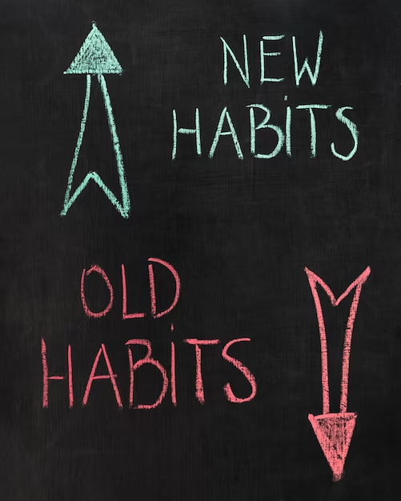

Un buen objetivo. Fuente: neuro-class.com

## Actividad 1

Buscar y escribir el significado de: “old habits”, “new habits”, “hábito”, “virtud”, “vicio”.

## Actividad 1

En base a las explicaciones de clase poner un título conveniente y copiar este texto en la carpeta poniendo en cada “raya” la palabra correcta que falta (en cada raya va una sola palabra).

La adolescencia es una etapa de muchos ______: físicos, emocionales y sociales. Durante estos años, el cuerpo crece y se desarrolla, y la mente empieza a tomar decisiones más complejas.

Los hábitos de salud son fundamentales en esta ______. Dormir bien, alimentarse de forma equilibrada y hacer actividad física ayudan al cuerpo a ______ correctamente. También es _____ cuidar la salud emocional y aprender a manejar el estrés, los cambios de humor y las relaciones con amigos y familiares.

Hoy los adolescentes ______ retos nuevos: el uso de redes sociales, la exposición a información rápida y a veces confusa, y las presiones escolares o sociales. Esto ______ afectar el sueño, la alimentación y la autoestima.

Aprender a reconocer estos cambios y tomar decisiones saludables es un paso importante para sentirse bien y enfrentar los desafíos de la _____ cotidiana.

## Actividad 3

Armar un juego de palabras cruzadas usando las palabras del texto anterior. También se puede usar sinónimos de las palabras.